# BIOST 561: Homework 2

Due date: 7:00pm on Monday, April 22nd, 2024

# Q0: Setting up`UWBiost561` package

**Question 0C**: Make sure you can load your package. (You need the `bookdown` package to knit the homework, similar to HW1.)

```r
library(bookdown)
library(tidyverse)
```

```r
library(ggplot2)
```

# Q1: Practice using tibbles

Dataset 1

```r
country_population <- readr::read_csv("https://raw.githubusercontent.com/linnykos/561_s2024_public/main/HW2_files/country_population.csv")
country_population
```

```
#> # A tibble: 13,545 × 4
#>    iso3c country  year population
#>    <chr> <chr>   <dbl>      <dbl>
#>  1 ABW   Aruba    1960      54608
#>  2 ABW   Aruba    1961      55811
#>  3 ABW   Aruba    1962      56682
#>  4 ABW   Aruba    1963      57475
#>  5 ABW   Aruba    1964      58178
#>  6 ABW   Aruba    1965      58782
#>  7 ABW   Aruba    1966      59291
#>  8 ABW   Aruba    1967      59522
#>  9 ABW   Aruba    1968      59471
#> 10 ABW   Aruba    1969      59330
#> # ℹ 13,535 more rows
```

Dataset 2

```r
country_birth <- readr::read_csv("https://raw.githubusercontent.com/linnykos/561_s2024_public/main/HW2_files/country_birth.csv")
country_birth
```

```
#> # A tibble: 5,486 × 5
#>    iso3c  year life_expect birth_rate neonat_mortal_rate
#>    <chr> <dbl>       <dbl>      <dbl>              <dbl>
#>  1 AND    1994          NA       10.9                3.2
#>  2 AND    1995          NA       11                  3
#>  3 AND    2006          NA       10.6                1.9
#>  4 AND    2007          NA       10.1                1.8
#>  5 AND    1996          NA       10.9                2.8
#>  6 AND    1993          NA       11.4                3.4
#>  7 AND    1997          NA       11.2                2.6
#>  8 AND    1998          NA       11.9                2.4
#>  9 AND    2008          NA       10.4                1.8
#> 10 AND    2009          NA        9.9                1.7
#> # ℹ 5,476 more rows
```

This question will allow you to practice basic data manipulation of these two `tibble` objects.

**Question 1A**:

```r
result_1a <- country_population %>%
  filter(year >= 1990 & year <= 2010) %>%
  group_by(iso3c) %>%
  summarize(mean_population = mean(population), na.rm=TRUE)

print(result_1a)
```

```
#> # A tibble: 215 × 3
#>    iso3c mean_population na.rm
#>    <chr>           <dbl> <lgl>
#>  1 ABW            85839. TRUE
#>  2 AFG         19819866. TRUE
#>  3 AGO         16829911. TRUE
#>  4 ALB          3095489. TRUE
#>  5 AND            67825. TRUE
#>  6 ARE          3858774. TRUE
#>  7 ARG         36972314. TRUE
#>  8 ARM          3211816. TRUE
#>  9 ASM            54995. TRUE
#> 10 ATG            74385. TRUE
#> # ℹ 205 more rows
```

**Question 1B**:

```r
result_1b <- country_birth %>%
  filter(year >= 1990 & year <= 2010) %>%
  select(iso3c, year, life_expect) %>%
  drop_na() %>%
  group_by(iso3c) %>%
  summarize(
    max_life_expect = round(max(life_expect), digits=2),
    min_life_expect = round(min(life_expect), digits=2)
  ) %>%
  mutate(range_life_expect = round(max_life_expect - min_life_expect, digits=2))

print(result_1b)
```

```
#> # A tibble: 203 × 4
#>    iso3c max_life_expect min_life_expect range_life_expect
#>    <chr>           <dbl>           <dbl>             <dbl>
#>  1 ABW              75.0            73.4              1.56
#>  2 AFG              59.0            49.9              9.11
#>  3 AGO              50.6            41.1              9.51
#>  4 ALB              77.0            71.9              5.14
#>  5 ARE              76.7            71.7              4.96
#>  6 ARG              75.5            71.5              3.94
#>  7 ARM              74.2            67.7              6.49
#>  8 ATG              75.3            71.2              4.15
#>  9 AUS              81.7            77.0              4.71
#> 10 AUT              80.6            75.6              5.01
#> # ℹ 193 more rows
```

**Question 1C**:

```r
country_both <- inner_join(country_population, country_birth, by = "iso3c")
print(head(country_both, 10))
```

```
#> # A tibble: 10 × 8
#>    iso3c country year.x population year.y life_expect birth_rate neonat_mortal_rate
#>    <chr> <chr>    <dbl>      <dbl>  <dbl>       <dbl>      <dbl>              <dbl>
#>  1 ABW   Aruba     1960      54608   1990        73.4       19.6                 NA
#>  2 ABW   Aruba     1960      54608   1992        73.5       18.4                 NA
#>  3 ABW   Aruba     1960      54608   1994        73.5       17.3                 NA
#>  4 ABW   Aruba     1960      54608   2006        74.4       12.0                 NA
#>  5 ABW   Aruba     1960      54608   2003        74.0       13.0                 NA
#>  6 ABW   Aruba     1960      54608   1993        73.5       17.9                 NA
#>  7 ABW   Aruba     1960      54608   2005        74.2       12.3                 NA
#>  8 ABW   Aruba     1960      54608   2007        74.5       11.7                 NA
#>  9 ABW   Aruba     1960      54608   1996        73.6       16.1                 NA
#> 10 ABW   Aruba     1960      54608   2004        74.1       12.7                 NA
```

```r
dimensions <- dim(country_both)
print(paste("Rows:", dimensions[1], "Columns:", dimensions[2]))
```

```
#> [1] "Rows: 343980 Columns: 8"
```

# Q2: Practice using ggplot via scatterplots and facets

```r
penguins <- readr::read_csv("https://raw.githubusercontent.com/linnykos/561_s2024_public/main/HW2_files/palmerpenguins.csv")
penguins
```

```
#> # A tibble: 333 × 8
#>    species island    bill_length_mm bill_depth_mm flipper_length_mm body_mass_g sex     year
#>    <chr>   <chr>              <dbl>         <dbl>             <dbl>       <dbl> <chr>  <dbl>
#>  1 Adelie  Torgersen           39.1          18.7               181        3750 male    2007
#>  2 Adelie  Torgersen           39.5          17.4               186        3800 female  2007
#>  3 Adelie  Torgersen           40.3          18                 195        3250 female  2007
#>  4 Adelie  Torgersen           36.7          19.3               193        3450 female  2007
#>  5 Adelie  Torgersen           39.3          20.6               190        3650 male    2007
#>  6 Adelie  Torgersen           38.9          17.8               181        3625 female  2007
#>  7 Adelie  Torgersen           39.2          19.6               195        4675 male    2007
#>  8 Adelie  Torgersen           41.1          17.6               182        3200 female  2007
#>  9 Adelie  Torgersen           38.6          21.2               191        3800 male    2007
#> 10 Adelie  Torgersen           34.6          21.1               198        4400 male    2007
#> # ℹ 323 more rows
```

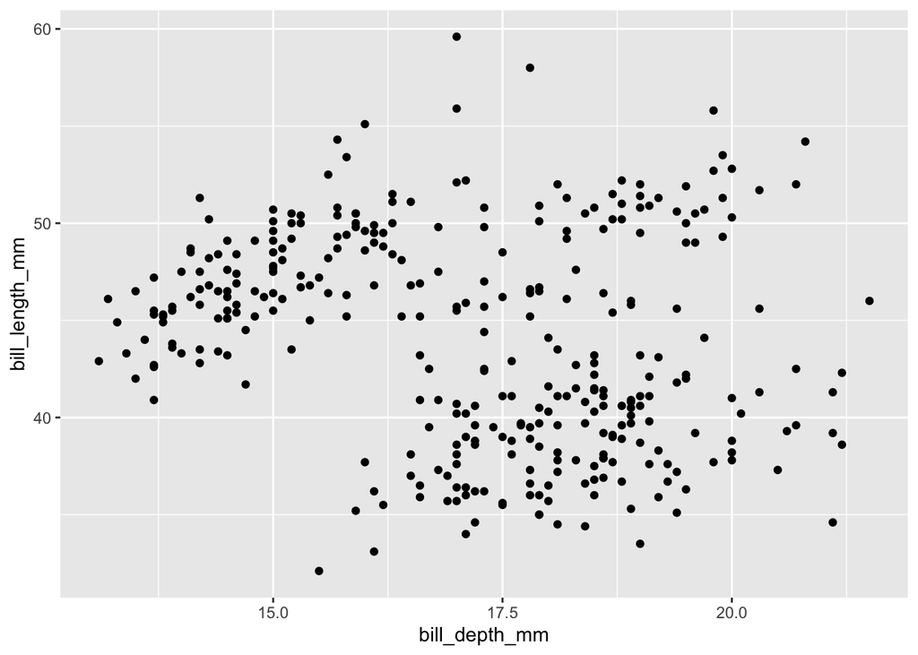

```r
penguins %>%
  ggplot(aes(x = bill_depth_mm, y = bill_length_mm)) +
  geom_point()
```

**Question 2A**:

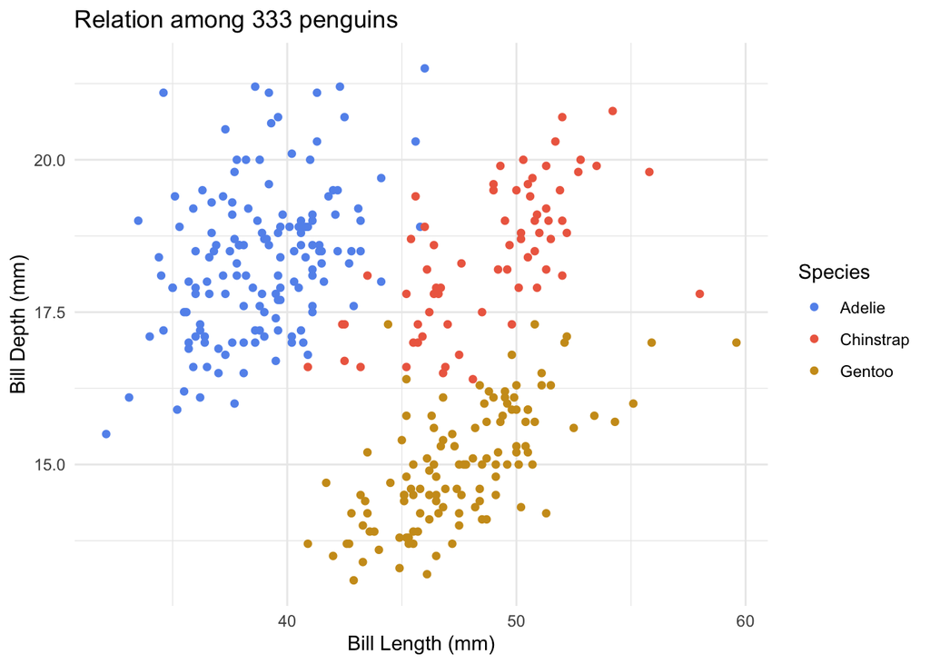

```r
plt_2a <- ggplot(penguins, aes(x = bill_length_mm, y = bill_depth_mm, color = species)) +
  geom_point() +  # Add points
  scale_color_manual(values = c("Adelie" = "cornflowerblue",
                                "Chinstrap" = "coral2",
                                "Gentoo" = "goldenrod3")) +
  labs(
    x = "Bill Length (mm)",
    y = "Bill Depth (mm)",
    title = paste("Relation among", nrow(penguins), "penguins"),
    color = "Species"
  ) +
  theme_minimal()

# Print the plot
print(plt_2a)
```

**Question 2B**:

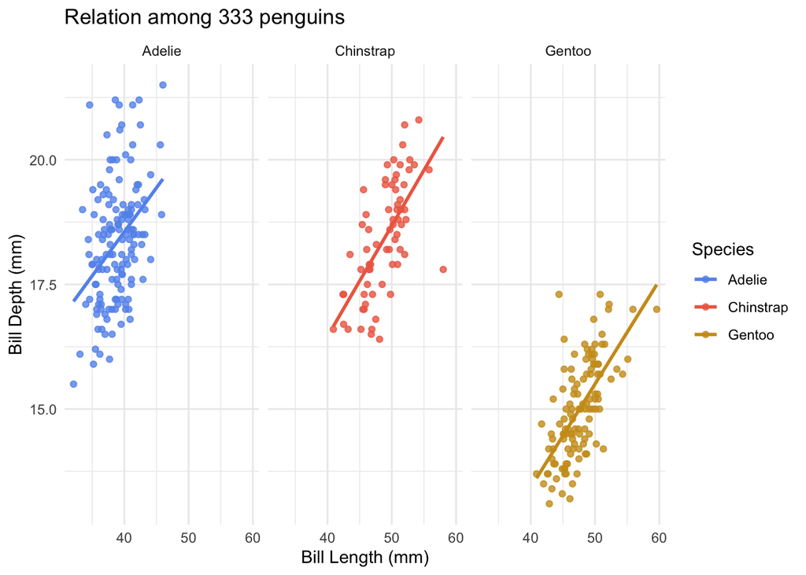

```r
# Create the plot with facets, regression lines, and adjusted point transparency
plt_2b <- ggplot(penguins, aes(x = bill_length_mm, y = bill_depth_mm)) +
  geom_point(aes(color = species), alpha = 0.8) +
  geom_smooth(method = "lm", aes(color = species), se = FALSE) +
  scale_color_manual(values = c("Adelie" = "cornflowerblue",
                                "Chinstrap" = "coral2",
                                "Gentoo" = "goldenrod3")) +
  facet_wrap(~species) +
  labs(
    x = "Bill Length (mm)",
    y = "Bill Depth (mm)",
    title = paste("Relation among", nrow(penguins), "penguins"),
    color = "Species"
  ) +
  theme_minimal()

# Print the plot
print(plt_2b)
```

# Q3: Practice using ggplot via heatmaps

```r
source("https://raw.githubusercontent.com/linnykos/561_s2024_public/main/HW2_files/random_graph_functions.R")
```

```r
set.seed(0)
result <- generate_random_graph(n = 20,
                                clique_fraction = 0.5,
                                density_low = 0.1)
adj_mat <- result$adj_mat
dim(adj_mat)
```

```
#> [1] 20 20
```

```r
adj_mat[1:5,1:5]
```

```
#>      [,1] [,2] [,3] [,4] [,5]
#> [1,]    1    0    1    0    0
#> [2,]    0    1    1    1    1
#> [3,]    1    1    1    0    0
#> [4,]    0    1    0    1    0
#> [5,]    0    1    0    0    1
```

**Question 3A**:

The `generate_random_graph()` function in R creates a random graph with a specified number of nodes. It includes a portion where all nodes are connected to each other, called a clique, which can be adjusted in size. Additionally, the function sets a low chance for connections between other nodes outside this clique, creating a sparser network. The graph is symmetrical, meaning connections are two-way, and node positions in the network are shuffled to randomize their placement. This method allows for the simulation of networks with both tightly-knit groups and more loosely connected components.

**Question 3B**:

The `pivot_longer_heatmap()` function converts an adjacency matrix into a long format suitable for heatmap visualization. It turns the matrix into a `tibble`, names the columns to represent nodes, adds row numbers, and then uses `pivot_longer()` to create a format where each row shows a connection status between two nodes. This transformation makes it easier to plot the data as a heatmap in `ggplot2`, with each row representing an interaction between a pair of nodes.

```r
mat_long <- pivot_longer_heatmap(adj_mat)
mat_long
```

```
#> # A tibble: 400 × 3
#>        X     Y Value
#>    <int> <dbl> <dbl>
#>  1     1     1     1
#>  2     1     2     0
#>  3     1     3     1
#>  4     1     4     0
#>  5     1     5     0
#>  6     1     6     1
#>  7     1     7     0
#>  8     1     8     0
#>  9     1     9     0
#> 10     1    10     0
#> # ℹ 390 more rows
```

**Question 3C**:

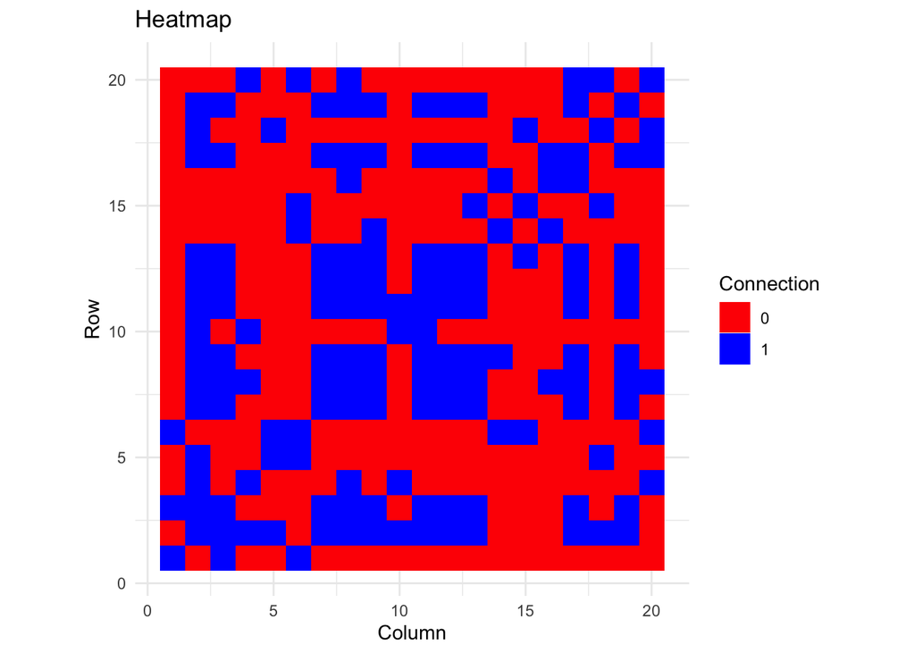

```r
plt_p3c <- ggplot(mat_long, aes(x = X, y = Y, fill = as.factor(Value))) +
  geom_tile() +
  scale_fill_manual(values = c("0" = "red", "1" = "blue")) +
  labs(title = "Heatmap", x = "Column", y = "Row", fill = "Connection") +
  coord_fixed(ratio = 1) +
  theme_minimal()

print(plt_p3c)
```

**Question 3D**: Congratulations! You have a working pipeline to visualize any adjacency matrix. For this last question, we will combine all your functions to visualize the following:

```r
adj_mat2 <- result$adj_mat[result$rev_order, result$rev_order]
```

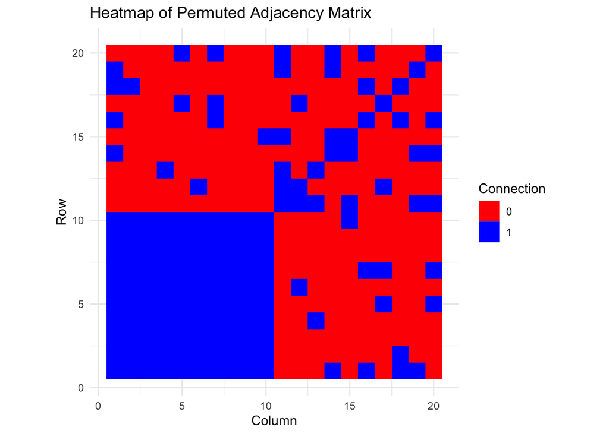

```r
mat_long2 <- pivot_longer_heatmap(adj_mat2)

plt_p3d <- ggplot(mat_long2, aes(x = X, y = Y, fill = as.factor(Value))) +
  geom_tile() +  # Use geom_tile() to create the heatmap tiles
  scale_fill_manual(values = c("0" = "red", "1" = "blue")) +
  labs(title = "Heatmap of Permuted Adjacency Matrix", x = "Column", y = "Row", fill = "Connection") +
  coord_fixed(ratio = 1) +  # Set the aspect ratio to 1:1
  theme_minimal()  # Use a minimal theme for a cleaner look


print(plt_p3d)
```

# Q4: Planning for the next homework – thinking how to test a function

1. (sanity check) Create specific test cases that cover a wide range of graph types, including edge cases such as graphs with no edges, graphs where every node is connected to every other node (complete graphs), and graphs with multiple maximal cliques of the same size. Each test should verify that the function accurately identifies the largest clique.
2. (Test with known ground truth) Use benchmark graphs for which the maximal cliques are already known and compare the function’s output against these known cliques. This could include both synthetic graphs and real-world networks where clique structures have been well-documented or theoretically established.
3. (Cross-Validation with other Algorithms): Compare the outputs of your function with those from established, trusted algorithms or software packages that find maximal cliques.
4. test that the function’s performance aligns with theoretical expectations for its algorithm class, especially in terms of time complexity.